# Programación en Lenguaje R

# Dr. Oldemar Rodríguez Rojas

# Funciones

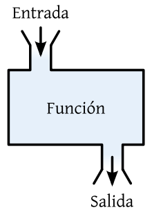

## Ejemplo 1

Calcula el área de un triángulo rectángulo

```r
area.triangulo <- function(base,altura) {
  area<-(base*altura)/2
  return(area)
}

area.triangulo(2,5)
```

```
[1] 5
```

```r
area.triangulo(4,5.8)
```

```
[1] 11.6
```

## Ejemplo 2

Una persona desea sacar un préstamo, de $P$ colones a una tasa de interés mensual $i$. El préstamo tiene que ser reembolsado en $n$ cuotas mensuales de tamaño $R$, comenzando dentro de un mes. El problema es calcular $R$. La fórmula $R$ es:

$$R = P \cdot \left( \frac{i}{1 − (1 + i)^{−n}} \right)$$

Si supongamos que $P=150000$, que la tasa de interés es del 2% y que le número de pagos es 10. EL código en R sería:

```r
tasa.interes <- 0.02
n <- 10
principal <- 150000
pago <- principal * tasa.interes / (1 - (1 + tasa.interes)^(-n))
pago
```

```
[1] 16698.98
```

Sería mejor escribir una función en R para este cálculo como sigue:

```r
calcula.cuota <- function(tasa.interes,n,principal) {
   pago <- principal * tasa.interes / (1 - (1 + tasa.interes)^(-n))
   return(pago)
}

calcula.cuota(0.02,10,150000)
```

```
[1] 16698.98
```

```r
calcula.cuota(0.11,340,3500000)
```

```
[1] 385000
```

## Ejemplo 3

Calcula la medida de la hipotenusa de un triángulo rectangulo

```r
hipotenusa.triangulo = function(cateto1,cateto2) {
  hip<-sqrt(cateto1^2+cateto2^2)
  return(hip)
}

hipotenusa.triangulo(2,5)
```

```
[1] 5.385165
```

```r
hipotenusa.triangulo(4,5.8)
```

```
[1] 7.045566
```

```r
hipotenusa.triangulo = function(cateto1,cateto2) {
  return(sqrt(cateto1^2+cateto2^2))
}

hipotenusa.triangulo(2,5)
```

```
[1] 5.385165
```

```r
hipotenusa.triangulo(4,5.8)
```

```
[1] 7.045566
```

## Ejemplo 4

La siguiente función que permita convertir de grados centígrados a Fahrenheit:

```r
Farenheit <- function(n){
    return (32 + 1.8 *n)
}

Farenheit(6)
```

```
[1] 42.8
```

```r
Farenheit(29)
```

```
[1] 84.2
```

## Ejemplo 5

Función para calcular el factorial de $n$ que se define como $n=1\cdot 2\cdot 3 \cdots n$

```r
factorial <- function(n) {
    fact <- prod(1:n)
    return(fact)
}

factorial(9)
```

```
[1] 362880
```

## Ejemplo 6

Función para calcular las combinaciones $r$ en $n$ que se define como:

$$\left(
\begin{array}{c}
n \\
r \\
\end{array}
\right) = \frac{n!}{r!(n-r)!}$$

```r
combinaciones <- function(r, n) {
    comb <- factorial(n)/(factorial(r)*factorial(n-r))
    return(comb)
}

combinaciones(3,9)
```

```
[1] 84
```

## En una función el orden de los parámetros puede cambiarse

```r
combinaciones(3,9) # Orden por defecto
```

```
[1] 84
```

```r
combinaciones(n=9,r=3) # Para cambiar el orden se especifica el nombre del parámetro
```

```
[1] 84
```

```r
combinaciones(9,3)  # Da error por que r debe ser menor a n
```

```
[1] Inf
```

# La sentencia if

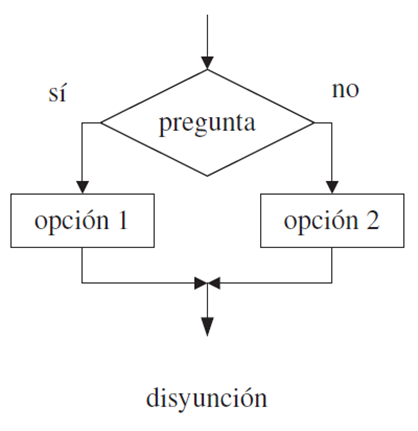

## Ejemplo 7

Retorna el numero más grande entre $a$ y $b$:

```r
mas.grande <- function(a,b) {
  if (a > b) {
    return(a)
  }
  else {
    return(b)
  }
}

mas.grande(pi,3)
```

```
[1] 3.141593
```

## Ejemplo 8

Función que recibe $x$ y retorna el valor absoluto de $|x|$:

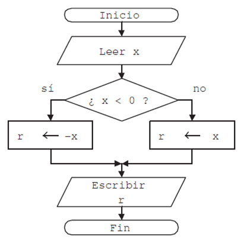

```r
valor.absoluto <- function(x) {
  if (x > 0) {
    r<-x
  }
  else {
    r<-(-x)
  }
  return(r)
}

valor.absoluto(3)
```

```
[1] 3
```

```r
valor.absoluto(-6)
```

```
[1] 6
```

## Ejemplo 9

Función R que recibe un par $(x,y)$ y retorna el cuadrante en donde se encuentra el punto.

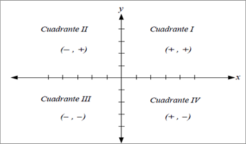

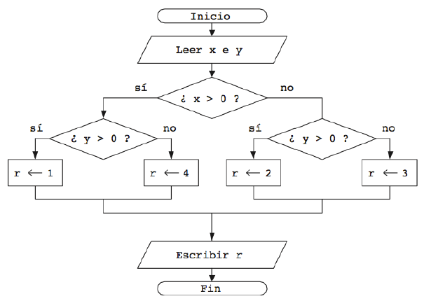

```r
cuadrante <- function(x,y) {
  if (x > 0) {
    if(y > 0) {
      r<-1
    }
    else {
      r<-4
    }
  }
  else {
    if(y > 0) {
      r<-2
    }
    else {
      r<-3
    }
  }
  return(r)
}

cuadrante(4,3)
```

```
[1] 1
```

```r
cuadrante(-6,1)
```

```
[1] 2
```

## Ejemplo 10

Función que calcula la correlación entre 2 vectores $x$ y $y$, además si la opción “plotear” se establece en “TRUE” la función además grafica los vectores. Por defecto la opción plotear está en “FALSE”

```r
cor.plot <- function(x, y, plotear=FALSE) {
  if(plotear == TRUE)
      plot(x,y)
  return(cor(x,y))
}

vec1<-runif(50)
vec2<-rnorm(50)
cor.plot(vec1,vec2)
```

```
[1] -0.1657045
```

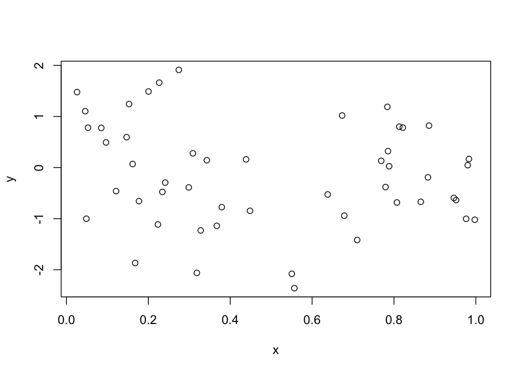

```
[1] -0.1657045
```

```r
cor.plot(vec1,vec2,TRUE)
```

## Ejemplo 11

Este algoritmo dados tres valores almacenarlos en las variables A, B y C retorna cual es el mayor.

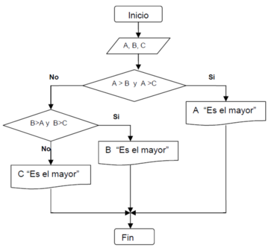

Nota: && = AND, || = OR y ! = NOT

```r
mayor <- function(A,B,C) {
  if((A > B) && (A > C)) {
    return(A)
  }
  else {
    if((B > A) && (B > C)) {
      return(B)
    }
    else {
      return(C)
    }
  }
}

mayor(9,0,2)
```

```
[1] 9
```

```r
mayor(0,-6,-3)
```

```
[1] 0
```

```r
mayor(1,2,2)
```

```
[1] 2
```

# La sentencia for

## Sintaxis:

#### for (variable in vector) {

#### expresion1

#### expresion2

#### expresion3

## Ejemplo 12

```r
aleatorios <- rnorm(10)
for (x in aleatorios) {
   print(x)
}
```

```
[1] 1.640458
[1] -0.2242381
[1] -0.7515202
[1] 0.671384
[1] -1.413996
[1] -0.7371901
[1] -0.8521771
[1] -0.7097635
[1] 0.02217869
[1] 0.2748643
```

## Ejemplo 13

```r
for (x in c(1:10))
  print(sqrt(x))
```

```
[1] 1
[1] 1.414214
[1] 1.732051
[1] 2
[1] 2.236068
[1] 2.44949
[1] 2.645751
[1] 2.828427
[1] 3
[1] 3.162278
```

## Ejemplo 14

```r
for (x in c(1:10))
 cat("Para x=", x, "La raíz cuadrada es:", sqrt(x),"\n")
```

```
Para x= 1 La raíz cuadrada es: 1
Para x= 2 La raíz cuadrada es: 1.414214
Para x= 3 La raíz cuadrada es: 1.732051
Para x= 4 La raíz cuadrada es: 2
Para x= 5 La raíz cuadrada es: 2.236068
Para x= 6 La raíz cuadrada es: 2.44949
Para x= 7 La raíz cuadrada es: 2.645751
Para x= 8 La raíz cuadrada es: 2.828427
Para x= 9 La raíz cuadrada es: 3
Para x= 10 La raíz cuadrada es: 3.162278
```

## Ejemplo 15

Función R que construye un vector “$v$” tal que en la entrada $k$ esté el valor $k^2-4$, es decir, $v[k]=k^2-4$:

```r
cvector.f <- function(n) {
  v<-rep(0,n) # Inicializa un vector con n ceros
  for(k in 1:n) {
    v[k]<-k^2-4
  }
  return(v)
}

cvector.f(9)
```

```
[1] -3  0  5 12 21 32 45 60 77
```

```r
cvector.f(35)
```

```
 [1]   -3    0    5   12   21   32   45   60   77   96  117  140  165  192
[15]  221  252  285  320  357  396  437  480  525  572  621  672  725  780
[29]  837  896  957 1020 1085 1152 1221
```

## Ejemplo 16

La siguiente función calcula la suma del valor absoluto de las entradas de un vector, es de decir, la norma 1 del vector dada por $|v[1]|+|v[2]|+\cdots+|v[n]|$:

```r
norma1.f <- function(v) {
   suma <- 0
   for(i in 1:length(v)) {
      suma <- suma + abs(v[i])
   }
   return(suma)
}

vec0<-c(4,-7,2,1)
norma1.f(vec0)
```

```
[1] 14
```

```r
vec1<-runif(50,-1,1)
norma1.f(vec1)
```

```
[1] 26.84163
```

```r
vec2<-rnorm(50,-1,1)
norma1.f(vec2)
```

```
[1] 48.62744
```

## Ejemplo 17

La siguiente función encuentra la primera pocisión en un vector en la que se encuentra en valor 0. La siguiente es una versión con “for”.

```r
encuentra.cero.f <- function(v) {
  s <- -1
  for(i in 1:length(v)) {
    if((v[i]==0) && (s == -1)) {
      s<-i
    }
  }
  if (s != -1) {
    return(s)
  }
  else {
    return("¡El vector no tiene ningún cero!")
  }
}

vec<-c(4,-7,2,1,9)
encuentra.cero.f(vec)
```

```
[1] "¡El vector no tiene ningún cero!"
```

```r
vec<-c(4,-7,2,0,9,98,0,9,-1)
encuentra.cero.f(vec)
```

```
[1] 4
```

# La sentencia while

## Ejemplo 18

Función R que construye un vector “$v$” tal que en la entrada $k$ esté el valor $k^{2}-4$, es decir, $v[k]=k^{2}-4$:

```r
cvector <- function(n) {
  v<-rep(0,n) # Inicializa un vector con n ceros
  k<-1
  while(k<=n) {
    v[k]<-k^2-4
    k<-k+1
  }
  return(v)
}

cvector(9)
```

```
[1] -3  0  5 12 21 32 45 60 77
```

```r
cvector(35)
```

```
 [1]   -3    0    5   12   21   32   45   60   77   96  117  140  165  192
[15]  221  252  285  320  357  396  437  480  525  572  621  672  725  780
[29]  837  896  957 1020 1085 1152 1221
```

## Ejemplo 19

La siguiente función calcula la suma del valor absoluto de las entradas de un vector, es de decir, la norma 1 del vector dada por $|v[1]|+|v[2]|+\cdots+|v[n]|$:

```r
norma1 <- function(v) {
   suma <- 0
   i = 1
   while (i <= length(v)) {
      suma <- suma + abs(v[i])
      i <- i + 1
   }
   return(suma)
}

vec0<-c(4,-7,2,1)
norma1(vec0)
```

```
[1] 14
```

```r
vec1<-runif(50,-1,1)
norma1(vec1)
```

```
[1] 26.68798
```

```r
vec2<-rnorm(50,-1,1)
norma1(vec2)
```

```
[1] 61.14583
```

## Ejemplo 20

La siguiente función encuentra la primera pocisión en un vector en la que se encuentra en valor 0:

```r
encuentra.cero <- function(v) {
  i <- 1
  while(v[i]!=0 && i<=length(v)) {
    i <- i + 1
  }
  if (i <= length(v)) {
    return(i)
  }
  else {
    return("¡El vector no tiene ningún cero!")
  }
}

vec<-c(4,-7,2,1,9)
encuentra.cero(vec)
```

```
[1] "¡El vector no tiene ningún cero!"
```

```r
vec<-c(4,-7,2,0,9)
encuentra.cero(vec)
```

```
[1] 4
```

# La sentencia repeat

## Ejemplo 21

Función R que construye un vector “$v$” tal que en la entrada $k$ esté el valor $k^2-4$, es decir, $v[k]=k^2-4$:

```r
cvector.r <- function(n) {
  v<-rep(0,n) # Inicializa un vector con n ceros
  k<-1
  repeat {
    v[k]<-k^2-4
    k<-k+1
    if(k>n) {
      break
    }
  }
  return(v)
}

cvector.r(9)
```

```
[1] -3  0  5 12 21 32 45 60 77
```

```r
cvector.r(35)
```

```
 [1]   -3    0    5   12   21   32   45   60   77   96  117  140  165  192
[15]  221  252  285  320  357  396  437  480  525  572  621  672  725  780
[29]  837  896  957 1020 1085 1152 1221
```

## Ejemplo 22

La siguiente función calcula la suma del valor absoluto de las entradas de un vector, es de decir, la norma 1 del vector dada por $|v[1]|+|v[2]|+\cdots+|v[n]|$:

```r
norma1.r <- function(v) {
   suma <- 0
   i = 1
   repeat {
      suma <- suma + abs(v[i])
      i <- i + 1
      if((i > length(v))) {
        break
      }
   }
   return(suma)
}

vec0<-c(4,-7,2,1)
norma1.r(vec)
```

```
[1] 22
```

```r
vec1<-runif(50,-1,1)
norma1.r(vec1)
```

```
[1] 24.67458
```

```r
vec2<-rnorm(50,-1,1)
norma1.r(vec2)
```

```
[1] 55.50378
```

## Ejemplo 23

La siguiente función encuentra la primera pocisión en un vector en la que se encuentra en valor 0:

```r
encuentra.cero.r <- function(v) {
  i <- 1
  repeat {
    if((v[i]==0 || i>length(v))) {
      break
    }
    i <- i + 1
  }
  if (i <= length(v)) {
    return(i)
  }
  else {
    return("¡El vector no tiene ningún cero!")
  }
}

vec<-c(4,-7,2,1,9)
encuentra.cero.r(vec)
```

```
[1] "¡El vector no tiene ningún cero!"
```

```r
vec<-c(4,-7,2,0,9)
encuentra.cero.r(vec)
```

```
[1] 4
```

# Ciclos Anidados

## Ejemplo 24

La siguiente función multiplica una matriz por un vector, es decir, calcula $y=Ax$ donde $A$ es una matriz de tamaño $m \times n$, $x$ es un vector (matriz) tamaño $n \times 1$ y por lo tanto $y$ es un vector (matriz) tamaño $m \times 1$.

```r
mat.x.vec <- function(A,x) {
  m <- nrow(A)
  n <- ncol(A)
  y <- matrix(0,nrow=m)
  for (j in 1:n) {
    for (i in 1:m) {
      y[i] <- y[i] + A[i,j]*x[j]
    }
  }
  return(y)
}

M <- matrix(c(2,3,-4,4,-8,2,0,1,-23,-2,4,0),4,3)
M
```

```
     [,1] [,2] [,3]
[1,]    2   -8  -23
[2,]    3    2   -2
[3,]   -4    0    4
[4,]    4    1    0
```

```r
v <- matrix(c(1,3,3),3,1)
v
```

```
     [,1]
[1,]    1
[2,]    3
[3,]    3
```

```r
res<-mat.x.vec(M,v)
res
```

```
     [,1]
[1,]  -91
[2,]    3
[3,]    8
[4,]    7
```

```r
# También se puede calcular como sigue:
res<-M%*%v
res
```

```
     [,1]
[1,]  -91
[2,]    3
[3,]    8
[4,]    7
```

## Ejemplo 25

La siguiente función verifica que dos matrices son del mismo tamaño.

```r
mismo.tamano <- function(A,B) {
  if((nrow(A)==nrow(B)) && (ncol(A)==ncol(B))) {
    return(TRUE)
  }
  else {
    return(FALSE)
  }
}

M1 <- matrix(c(2,3,-4,4,-8,2,0,1,-23,-2,4,0),4,3)
M1
```

```
     [,1] [,2] [,3]
[1,]    2   -8  -23
[2,]    3    2   -2
[3,]   -4    0    4
[4,]    4    1    0
```

```r
M2 <- matrix(c(0,0,0,1,1,2,0,1,-6,-2,1,0),4,3)
M2
```

```
     [,1] [,2] [,3]
[1,]    0    1   -6
[2,]    0    2   -2
[3,]    0    0    1
[4,]    1    1    0
```

```r
mismo.tamano(M1,M2)
```

```
[1] TRUE
```

```r
M3 <- matrix(c(1,1,2,0,1,-6,-2,1,0),3,3)
M3
```

```
     [,1] [,2] [,3]
[1,]    1    0   -2
[2,]    1    1    1
[3,]    2   -6    0
```

```r
mismo.tamano(M1,M3)
```

```
[1] FALSE
```

## Ejemplo 26

La siguiente función suma dos matrices del mismo tamaño $m \times n$.

```r
# Esta función asume que A y B son del mismo tamaño
# Las validaciones nunca se hacen dentro de una función
suma.mat <- function(A,B) {
  m<-nrow(A)
  n<-ncol(A)
  C <- matrix(0,nrow=m,ncol=n)
  for (j in 1:n) {
    for (i in 1:m) {
      C[i,j] <- A[i,j]+B[i,j]
    }
  }
  return(C)
}

M1 <- matrix(c(2,3,-4,4,-8,2,0,1,-23,-2,4,0),4,3)
M1
```

```
     [,1] [,2] [,3]
[1,]    2   -8  -23
[2,]    3    2   -2
[3,]   -4    0    4
[4,]    4    1    0
```

```r
M2 <- matrix(c(0,0,0,1,1,2,0,1,-6,-2,1,0),4,3)
M2
```

```
     [,1] [,2] [,3]
[1,]    0    1   -6
[2,]    0    2   -2
[3,]    0    0    1
[4,]    1    1    0
```

```r
# Esto es una validación, las validaciones nunca se hacen dentro de una función
if(mismo.tamano(M1,M2)==TRUE) {
  M3<-suma.mat(M1,M2)
  M3
}
```

```
     [,1] [,2] [,3]
[1,]    2   -7  -29
[2,]    3    4   -4
[3,]   -4    0    5
[4,]    5    2    0
```

# Funciones para el manejo de datos

## Ejemplo 27:

La siguiente función en R recibe un DataFrame (DF) y retorna el valor máximo almacenado en DF

```r
maximo <- function(DF) {
  n<-dim(DF)[1]
  m<-dim(DF)[2]
  max<-DF[1,1]
  for(i in 1:n) {
    for(j in 1:m) {
      if(DF[i,j]>max) {
        max<-DF[i,j]
      }
    }
  }
  return(max)
}

setwd("~/Google Drive/MDCurso/Datos")
Datos<-read.table("EjemploEstudiantes.csv",header=TRUE,sep=";",dec=",",row.names=1)
maximo(Datos)
```

```
[1] 9.7
```

## Ejemplo 28: Retornando una lista de valores

La siguiente función en R recibe un DataFrame (DF) y retorna en una lista el valor mímimo, el máximo, la cantidad de ceros y la cantidad de números pares que contiene el dataFrame:

```r
valores <- function(DF) {
  n<-dim(DF)[1]
  m<-dim(DF)[2]
  min<-DF[1,1]
  max<-DF[1,1]
  t.ceros<-0
  t.pares<-0
  for(i in 1:n) {
    for(j in 1:m) {
      if(DF[i,j]>max) {
        max<-DF[i,j]
      }
      if(DF[i,j]<min) {
        min<-DF[i,j]
      }
      if(DF[i,j]==0) {
        t.ceros<-t.ceros+1
      }
      if((DF[i,j]%%2)==0) {
        t.pares<-t.pares+1
      }
    }
  }
  return(list(Maximo=max,Mimimo=min,Numero.Ceros=t.ceros,Pares=t.pares))
}

setwd("~/Google Drive/MDCurso/Datos")
Datos<-read.table("EjemploEstudiantes.csv",header=TRUE,sep=";",dec=",",row.names=1)
valores(Datos)
```

```
$Maximo
[1] 9.7

$Mimimo
[1] 5

$Numero.Ceros
[1] 0

$Pares
[1] 10
```

## Ejemplo 29:

La siguiente función en R recibe un DataFrame (DF) y un número de columna (NC) y que retorna en una lista el nombre de la variable correspondiente al número de columna, la media, la mediana, la desviación estándar,la varianza, el máximo y el mínimo:

```r
Estadisticas <- function(DF,NC) {
  media <- mean(DF[,NC])
  mediana <- median(DF[,NC])
  deviacion <- sd(DF[,NC])
  varianza <- var(DF[,NC])
  maximo <- max(DF[,NC])
  minimo <- min(DF[,NC])
  return(list(Variable=colnames(DF)[NC],Media=media,Mediana=mediana,DesEst=deviacion,Varianza=varianza,Maximo=maximo,Minimo=minimo))
}

setwd("~/Google Drive/MDCurso/Datos")
Datos<-read.table("EjemploEstudiantes.csv",header=TRUE,sep=";",dec=",",row.names=1)
Estadisticas(Datos,2)
```

```
$Variable
[1] "Ciencias"

$Media
[1] 7.65

$Mediana
[1] 6.85

$DesEst
[1] 1.609865

$Varianza
[1] 2.591667

$Maximo
[1] 9.7

$Minimo
[1] 6
```

```r
Estadisticas(Datos,4)
```

```
$Variable
[1] "Historia"

$Media
[1] 7.9

$Mediana
[1] 8

$DesEst
[1] 1.121507

$Varianza
[1] 1.257778

$Maximo
[1] 9

$Minimo
[1] 5.5
```

## Ejemplo 30:

El siguiente código plotea la matriz de correlaciones:

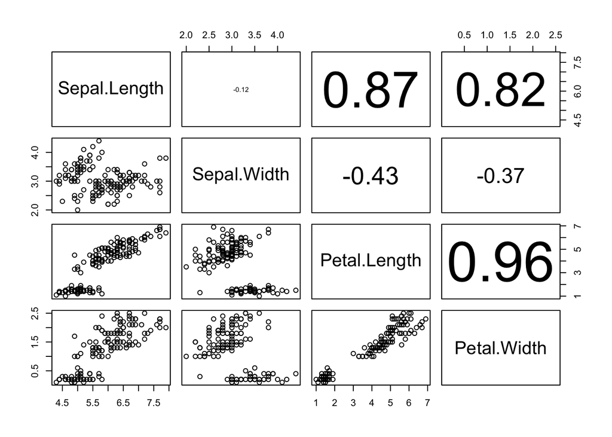

```r
panel.cor <- function(x, y, ...) {
    par(usr = c(0, 1, 0, 1))
    txt <- as.character(format(cor(x, y), digits=2))
    text(0.5, 0.5, txt,  cex = 6* abs(cor(x, y)))
}

pairs(iris[1:4], upper.panel=panel.cor)
```

# Recursión

## Recordemos que una Función Recursiva es aquella que se invoca a si misma.

## Ejemplo 31: Tres funciones diferentes para calcular el factorial de $n$

```r
# Aprovechando funciones predefinidas en R
factorial <- function(n) {
    fact <- prod(1:n)
    return(fact)
}

factorial(9)
```

```
[1] 362880
```

```r
# De forma iterativa
factorial1 <- function(n) {
  if(n==0)
    f <- 1
  else {
    f <- 1
      for (i in 1:n) {
        f <- f * i
      }
  }
    return(f)
}

factorial1(9)
```

```
[1] 362880
```

```r
# De forma recursiva como sigue:
factorial2 <- function(n) {
    if ((n==1)||(n==0)) {
        return(1)
    } else {
        return(n*factorial2(n-1))
    }
}

factorial2(9)
```

```
[1] 362880
```

## Ejemplo 32: La siguiente función calcula $x^n$ recursivamente

Para esto se usa que:

$$x^n = x \cdot x^{n-1}$$

```r
eleva.n <- function(x,n) {
   if(n==0) {
     return(1)
   }
   else {
     return(x*eleva.n(x,n-1))
   }
}

eleva.n(34,7)
```

```
[1] 52523350144
```

```r
# Verificando
34^7
```

```
[1] 52523350144
```

## Ejemplo 33: La siguiente función calcula la siguiente la relación de recurrencia $U_{n}$:

$$U_{n}=\left\{
\begin{array}{cl}
2U_{n-1}-U_{n-2} & \mbox{Si $n \geq 2$} \\
2 & \mbox{Si $n = 0$} \\
-3 & \mbox{Si $n = 1$} \\
\end{array}
\right.$$

```r
U <- function(n) {
   if(n==0) {
     return(2)
   }
   else {
     if(n==1) {
       return(-3)
     }
     else {
       return(2*U(n-1)-U(n-2))
     }
   }
}

U(9)
```

```
[1] -43
```